# Severe Weather Events Analysis

# Impact Of Severe Weather Events On Population Health and Economy Across The United States

## Synopsis

In this report, we analyze the U.S. National Oceanic and Atmospheric Administration’s (NOAA) storm database. This database provides the characteristics of severe weather events, time and location of occurance and estimated impact to humans, crops and property. The key objective of this analysis is to find out the following:

1. Across the United States, which types of events (as indicated in the EVTYPE variable) are most harmful with respect to population health?
2. Across the United States, which types of events have the greatest economic consequences?

This research was done with the data from the file (https://d396qusza40orc.cloudfront.net/repdata%2Fdata%2FStormData.csv.bz2) downloaded from Coursera website on May 20, 2015. The findings apply to the period between year 1980 and end in November 2011. Following are the key findings:

### Population Impact

1. TORNADO ranks #1 by causing 2274 fatalities. EXCESSIVE HEAT ranks #2 by causing 1903 fatalities
2. TORNADO ranks #1 by causing 37971 injuries. TSTM WIND ranks #2 by causing 6957 injuries

### Economic Impact

#### Crop Damage

1. DROUGHT ranks #1 by causing damage worth 13.9725B$ between year 1980 and 2011
2. FLOOD ranks #2 by causing damage worth 5.661B$ between year 1980 and 2011

## Global Settings

```r
echo = TRUE
```

## Data Processing

### Read the source data file into a data frame

We assume that there is a data directory in the current directory where this file exists.

```r
if(!file.exists("data/repdata-data-StormData.csv.bz2"))
  error("Data file does not exist in the current directory. Are we in the right directory")
sev.Data <- read.csv("data/repdata-data-StormData.csv.bz2")
```

Our objective is to find the most harmful events across the United States. First we will see the data spread. We have 902297 records in the full data set.

```r
sev.Data$Year <- as.numeric(format(as.Date(sev.Data$BGN_DATE, format = "%m/%d/%Y %H:%M:%S"), "%Y"))
```

```r
sev.Data <- sev.Data[sev.Data$Year >= 1980 ,]
```

### Compact The Data Set

```r
compact.Data <- sev.Data[,c(7,8, 23:28)]
compact.Data$EVTYPE <- as.character(compact.Data$EVTYPE)
```

After compacting, the data looks as below:

```r
head(compact.Data,3)
```

```
##      STATE EVTYPE FATALITIES INJURIES PROPDMG PROPDMGEXP CROPDMG
## 2018    AL   HAIL          0        0       0                  0
## 2019    AL   HAIL          0        0       0                  0
## 2020    AL   HAIL          0        0       0                  0
##      CROPDMGEXP
## 2018
## 2019
## 2020
```

### Aggregate Fatalities And Injuries Data

We can now aggregate the fatalities by the various event types.

```r
fatalities.Data <- aggregate(compact.Data$FATALITIES, by=list(EVTYPE=compact.Data$EVTYPE), FUN=sum)
fatalities.Data <- fatalities.Data[order(fatalities.Data$x, decreasing=T),]
colnames(fatalities.Data) <- c("WEATHER_EVENT", "NO_OF_FATALITIES")
state.fatalities.Data <- aggregate(compact.Data$FATALITIES, by=list(EVTYPE=compact.Data$EVTYPE,STATE=compact.Data$STATE), FUN=sum)
```

This is how the top **aggregate fatalities** data looks like for the period 1980 to end November 2011, shown in decreasing order of fatalities.

```r
head(fatalities.Data, 10)
```

```
##      WEATHER_EVENT NO_OF_FATALITIES
## 834        TORNADO             2274
## 130 EXCESSIVE HEAT             1903
## 153    FLASH FLOOD              978
## 275           HEAT              937
## 464      LIGHTNING              816
## 856      TSTM WIND              504
## 170          FLOOD              470
## 585    RIP CURRENT              368
## 359      HIGH WIND              248
## 19       AVALANCHE              224
```

Similarly we can aggregate the injuries by the various event types.

```r
injuries.Data <- aggregate(compact.Data$INJURIES, by=list(EVTYPE=compact.Data$EVTYPE), FUN=sum)
injuries.Data <- injuries.Data[order(injuries.Data$x, decreasing=T),]
colnames(injuries.Data) <- c("WEATHER_EVENT", "NO_OF_INJURIES")
state.injuries.Data <- aggregate(compact.Data$INJURIES, by=list(EVTYPE=compact.Data$EVTYPE,STATE=compact.Data$STATE), FUN=sum)
```

This is how the top **aggregate injuries** data looks like for the period 1980 to end November 2011, shown in decreasing order of injuries.

```r
head(injuries.Data, 10)
```

```
##         WEATHER_EVENT NO_OF_INJURIES
## 834           TORNADO          37971
## 856         TSTM WIND           6957
## 170             FLOOD           6789
## 130    EXCESSIVE HEAT           6525
## 464         LIGHTNING           5230
## 275              HEAT           2100
## 427         ICE STORM           1975
## 153       FLASH FLOOD           1777
## 760 THUNDERSTORM WIND           1488
## 244              HAIL           1361
```

### Compute Economic Impact

```r
propDmgValue <- as.numeric(compact.Data$PROPDMG)
cropDmgValue <- as.numeric(compact.Data$CROPDMG)
propMult <- numeric()
cropMult <- numeric()

# The power function take an ascii code (K,M,B) and converts it to
# a numeric <power> of 10 value

power <- function(code) {
  code <- toupper(code)
  return(ifelse(code == "", 1L,
          ifelse(code == "H",2L,
           ifelse(code == "K", 3L,
            ifelse(code == "M",6L,
             ifelse(code == "B",9L,
              ifelse(code == "+", 0L,
               ifelse(code == "-",0L,
                ifelse(code == "?", 0L,
                       as.numeric(code))))))))))
}

propMult <- 10 ^ power(compact.Data$PROPDMGEXP)
cropMult <- 10 ^ power(compact.Data$CROPDMGEXP)
# Very slow code below replaced by above two statements which
# end up doing the same stuff. Although the above code outputs some
# warnings, the results are the same
#
#for (i in 1:nrow(compact.Data)){
#  if(is.na(compact.Data$PROPDMG[i]))
#    propMult[i] <- 0
#  else
#    propMult[i] <- 10^convertCode(compact.Data$PROPDMGEXP[i])
#
#  if(is.na(compact.Data$CROPDMG[i]))
#    cropMult[i] <- 0
#  else
#    cropMult[i] <- 10^convertCode(compact.Data$CROPDMGEXP[i])
# }

propDmgValue <- propDmgValue * propMult
cropDmgValue <- cropDmgValue * cropMult

# Add the computed columns to the data frame

compact.Data$CropDamageValue <- cropDmgValue
compact.Data$PropDamageValue <- propDmgValue

# Aggregate Crop Damage by Weather Event

crop.Damage.Data <- aggregate(compact.Data$CropDamageValue, by=list(EVTYPE=compact.Data$EVTYPE), FUN=sum)
crop.Damage.Data <- crop.Damage.Data[order(crop.Damage.Data$x, decreasing=T),]
colnames(crop.Damage.Data) <- c("WEATHER_EVENT", "CROP_DAMAGE")

state.crop.Data <- aggregate(compact.Data$CropDamageValue, by=list(EVTYPE=compact.Data$EVTYPE,STATE=compact.Data$STATE), FUN=sum)

# Aggregate Property Damage by Weather Event

prop.Damage.Data <- aggregate(compact.Data$PropDamageValue, by=list(EVTYPE=compact.Data$EVTYPE), FUN=sum)
prop.Damage.Data <- prop.Damage.Data[order(prop.Damage.Data$x, decreasing=T),]
colnames(prop.Damage.Data) <- c("WEATHER_EVENT", "PROP_DAMAGE")
state.prop.Data <- aggregate(compact.Data$PropDamageValue, by=list(EVTYPE=compact.Data$EVTYPE,STATE=compact.Data$STATE), FUN=sum)
```

This is how the top **aggregate crop damage** data looks like for the period 1980 to end November 2011, shown in decreasing order of crop damage value.

```r
head(crop.Damage.Data,10)
```

```
##         WEATHER_EVENT CROP_DAMAGE
## 95            DROUGHT 13972566000
## 170             FLOOD  5661968450
## 590       RIVER FLOOD  5029459000
## 427         ICE STORM  5022113500
## 244              HAIL  3025954500
## 402         HURRICANE  2741910000
## 411 HURRICANE/TYPHOON  2607872800
## 153       FLASH FLOOD  1421317100
## 140      EXTREME COLD  1292973000
## 212      FROST/FREEZE  1094086000
```

This is how the top **aggregate property damage** data looks like for the period 1980 to end November 2011, shown in decreasing order of property damage value.

```r
head(prop.Damage.Data,10)
```

```
##         WEATHER_EVENT  PROP_DAMAGE
## 170             FLOOD 144657709870
## 411 HURRICANE/TYPHOON  69305840000
## 834           TORNADO  43648796374
## 670       STORM SURGE  43323536000
## 153       FLASH FLOOD  16822675842
## 244              HAIL  15735268026
## 402         HURRICANE  11868319010
## 848    TROPICAL STORM   7703890550
## 972      WINTER STORM   6688497251
## 359         HIGH WIND   5270046295
```

## Results

Following code prepares data for plotting. Summary of results can be found below the code section.

```r
library(ggplot2)
require(gridExtra)
options(scipen=99)
fatalities.Data <- fatalities.Data[1:10,]
injuries.Data <- injuries.Data[1:10,]
fatalities.Data$X <- factor(fatalities.Data$WEATHER_EVENT,levels=as.character(fatalities.Data$WEATHER_EVENT))
injuries.Data$X <- factor(injuries.Data$WEATHER_EVENT,levels=as.character(injuries.Data$WEATHER_EVENT))

state.fatalities.Data <- state.fatalities.Data[state.fatalities.Data$EVTYPE == fatalities.Data$WEATHER_EVENT[1],]
state.injuries.Data <- state.injuries.Data[state.injuries.Data$EVTYPE == injuries.Data$WEATHER_EVENT[1],]
state.fatalities.Data <- state.fatalities.Data[order(state.fatalities.Data$x, decreasing=T),]
state.injuries.Data <- state.injuries.Data[order(state.injuries.Data$x, decreasing=T),]

state.fatalities.Data <- state.fatalities.Data[1:10,]
state.fatalities.Data$XLABEL <- factor(state.fatalities.Data$STATE, levels=as.character(state.fatalities.Data$STATE))

state.injuries.Data <- state.injuries.Data[1:10,]
state.injuries.Data$XLABEL <- factor(state.injuries.Data$STATE, levels=as.character(state.injuries.Data$STATE))
#
crop.Damage.Data <- crop.Damage.Data[1:10,]
prop.Damage.Data <- prop.Damage.Data[1:10,]
crop.Damage.Data$X <- factor(crop.Damage.Data$WEATHER_EVENT,levels=as.character(crop.Damage.Data$WEATHER_EVENT))
prop.Damage.Data$X <- factor(prop.Damage.Data$WEATHER_EVENT,levels=as.character(prop.Damage.Data$WEATHER_EVENT))

state.crop.Data <- state.crop.Data[state.crop.Data$EVTYPE == crop.Damage.Data$WEATHER_EVENT[1],]
state.prop.Data <- state.prop.Data[state.prop.Data$EVTYPE == prop.Damage.Data$WEATHER_EVENT[1],]
state.crop.Data <- state.crop.Data[order(state.crop.Data$x, decreasing=T),]
state.prop.Data <- state.prop.Data[order(state.prop.Data$x, decreasing=T),]

state.crop.Data <- state.crop.Data[1:10,]
state.crop.Data$XLABEL <- factor(state.crop.Data$STATE, levels=as.character(state.crop.Data$STATE))

state.prop.Data <- state.prop.Data[1:10,]
state.prop.Data$XLABEL <- factor(state.prop.Data$STATE, levels=as.character(state.prop.Data$STATE))
```

### Events Causing Most Population Health Impact Across US

#### Fatalities

1. **TORNADO ranks #1** by causing **2274 fatalities** between year 1980 and 2011
2. **EXCESSIVE HEAT ranks #2** by causing **1903 fatalities** between year 1980 and 2011

#### Injuries

1. **TORNADO ranks #1** by causing **37971 injuries** between year 1980 and 2011
2. **TSTM WIND ranks #2** by causing **6957 injuries** between year 1980 and 2011

#### Graphical Visualization Of Top 10 Events For Adverse Population Health Impact

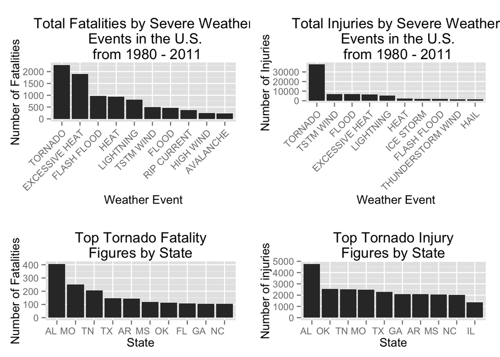

```r
plot.f <- ggplot(fatalities.Data, aes(x=X, y=NO_OF_FATALITIES)) +
    geom_bar(stat="identity") +
    scale_y_continuous("Number of Fatalities") +
    theme(axis.text.x = element_text(angle = 45,
    hjust = 1)) + xlab("Weather Event") +
    ggtitle("Total Fatalities by Severe Weather\n Events in the U.S.\n  from 1980 - 2011")

plot.sf <- ggplot(state.fatalities.Data, aes(x=XLABEL, y=x)) +
    geom_bar(stat="identity") +
    scale_y_continuous("Number of Fatalities") +
    theme(axis.text.x = element_text(angle = 0,
    hjust = 1)) + xlab("State") +
    ggtitle("Top Tornado Fatality\nFigures by State")

plot.i <- ggplot(injuries.Data, aes(x=X, y=NO_OF_INJURIES)) +
    geom_bar(stat="identity") +
    scale_y_continuous("Number of Injuries") +
    theme(axis.text.x = element_text(angle = 45,
    hjust = 1)) + xlab("Weather Event") +
    ggtitle("Total Injuries by Severe Weather\n Events in the U.S.\n from 1980 - 2011")

plot.si <- ggplot(state.injuries.Data, aes(x=XLABEL, y=x)) +
    geom_bar(stat="identity") +
    scale_y_continuous("Number of injuries") +
    theme(axis.text.x = element_text(angle = 0,
    hjust = 1)) + xlab("State") +
    ggtitle("Top Tornado Injury\nFigures by State")

grid.arrange(plot.f, plot.i, plot.sf, plot.si, nrow = 2, ncol = 2, heights = c( 0.6, 0.4))
```

### Events Causing Most Economic Damage Across US

#### Crop Damage

1. **DROUGHT ranks #1** by causing damage worth **13972566000 US Dollars** between year 1980 and 2011
2. **FLOOD ranks #2** by causing damage worth **5661968450 US Dollars** between year 1980 and 2011

#### Property Damage

1. **FLOOD ranks #1** by causing damage worth **144657709870 US Dollars** between year 1980 and 2011
2. **HURRICANE/TYPHOON ranks #2** by causing damage worth **69305840000 US Dollars** between year 1980 and 2011

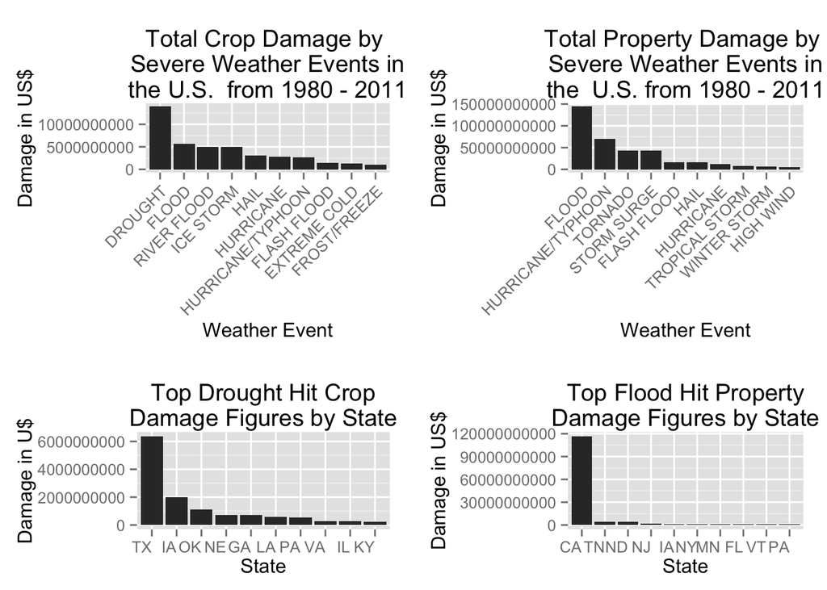

```r
plot.c <- ggplot(crop.Damage.Data, aes(x=X, y=CROP_DAMAGE)) +
    geom_bar(stat="identity") +
    scale_y_continuous("Damage in US$") +
    theme(axis.text.x = element_text(angle = 45,
    hjust = 1)) + xlab("Weather Event") +
    ggtitle("Total Crop Damage by \nSevere Weather Events in\nthe U.S.  from 1980 - 2011")

plot.sc <- ggplot(state.crop.Data, aes(x=XLABEL, y=x)) +
    geom_bar(stat="identity") +
    scale_y_continuous("Damage in U$") +
    theme(axis.text.x = element_text(angle = 0,
    hjust = 1)) + xlab("State") +
    ggtitle("Top Drought Hit Crop\nDamage Figures by State")

plot.p <- ggplot(prop.Damage.Data, aes(x=X, y=PROP_DAMAGE)) +
    geom_bar(stat="identity") +
    scale_y_continuous("Damage in US$") +
    theme(axis.text.x = element_text(angle = 45,
    hjust = 1)) + xlab("Weather Event") +
    ggtitle("Total Property Damage by \nSevere Weather Events in\nthe  U.S. from 1980 - 2011")

plot.sp <- ggplot(state.prop.Data, aes(x=XLABEL, y=x)) +
    geom_bar(stat="identity") +
    scale_y_continuous("Damage in US$") +
    theme(axis.text.x = element_text(angle = 0,
    hjust = 1)) + xlab("State") +
    ggtitle("Top Flood Hit Property\nDamage Figures by State")

grid.arrange(plot.c, plot.p, plot.sc, plot.sp, nrow = 2, ncol = 2,  heights = c( 0.6, 0.4))
```

## Observations

1. Weather events data in the data set needs further cleaning up. There are multiple entries for the same weather event type. This research used the Weather events data as is.